# QM Programming Basics 5 - Scripts and Functions

Class exercise: develop a program (code, script) to calculate hours of daylight as a function of latitude and day.

An outline of the code is in DaylightHoursOutline.R on Collab Resources/ClassCodes

How to query for a value? [Enter value in console]

```r
p = readline("enter # from 1 to 10")
```

```
## enter # from 1 to 10
```

```r
print(p)
```

```
## [1] ""
```

```r
p = readline("enter # from 1 to 10: ")
```

```
## enter # from 1 to 10:
```

```r
print(p)
```

```
## [1] ""
```

hmm.. Reads as char. Want a numeric value

```r
p = as.numeric(readline("enter # from 1 to 10: "))
```

```
## enter # from 1 to 10:
```

```r
print(p)
```

```
## [1] NA
```

Better.

Considerations: naming variables, informative heading for plot. If you complete this quickly, make new version that calculates daylight hours for latitudes from -65 to 65 for a specified day.

Fundamentally, daylight hours is a function of day and latitude, but run into a number of problems if you try just making them both vectors because we want to combine all values of each, not just first day with first latitude.

One way to solve the problem is to loop over possible latitudes and create a matrix of solutions. That involves reusing the code to calculate daylight hours repeatedly, which is a good reason to think about creating a function to do the calculation.

**Functions**

Functions are a way to do specific computing tasks (say finding mean) that you might want to do in a number of contexts.

They take input, return output based on a set of instructions or computations

All R math functions and other commands are actually just R function codes

Function format: FuncName = function(x) { Code for calculating y or whatever Return y }

In our daylight hours example, it would make sense to make a function of the daylight hrs calculation. That would allow us to use it in a variety of contexts.

```r
#calculates daylight hours for given latitude and yearday
daylighthrs = function(lat,yearday) {

    phir = lat*pi/180 #degree  #-> radians
    delta = 0.4093*sin(pi/180*yearday-1.405) #solar declination
    omegas = acos(-tan(phir)*tan(delta)) #sunset hour angle
    nhours = 24*omegas/pi #hours in day
    return(nhours)
}
```

Try it out…

```r
x = daylighthrs(45,200)
print(x)
```

```
## [1] 14.91281
```

Can we input a vector of days?

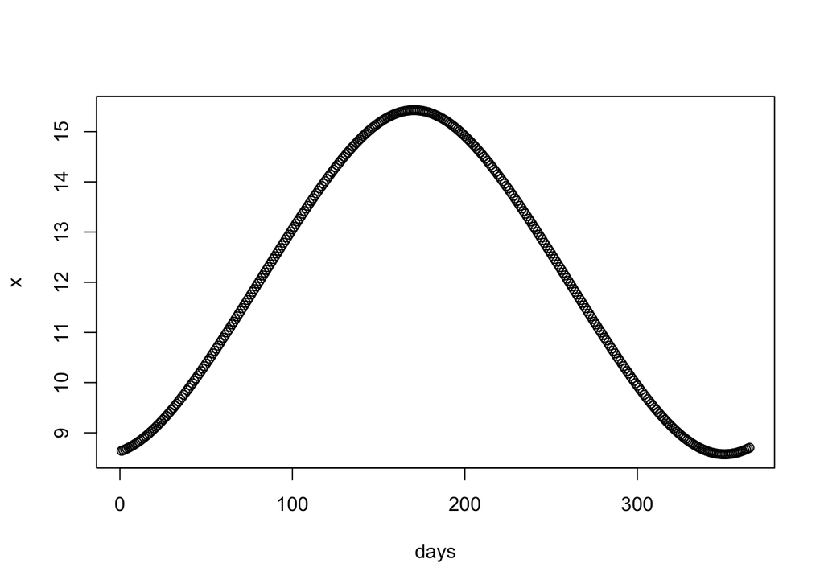

```r
days = 1:365
x = daylighthrs(45,days)
plot(days,x)
```

Yes!! also

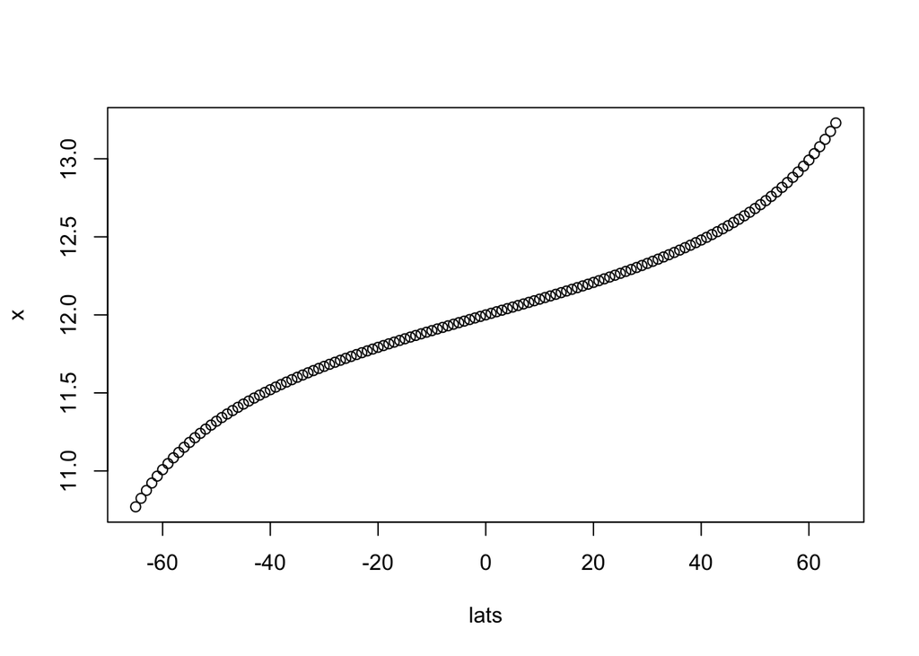

```r
lats = -65:65
day = 250
x = daylighthrs(lats,day)
plot(lats,x)
```

Now try

```r
lats = -65:65
days = 1:365
mx = daylighthrs(lats,days)
dim(mx)
```

[output not shown]

Calculated something, but not what we wanted.